# The Digital Against the Acoustic

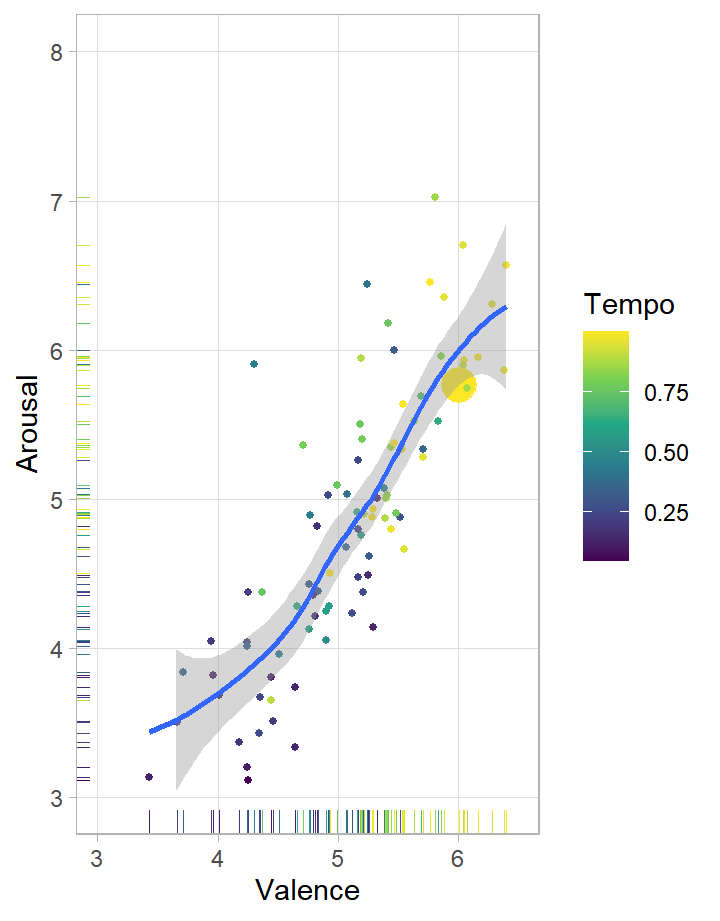

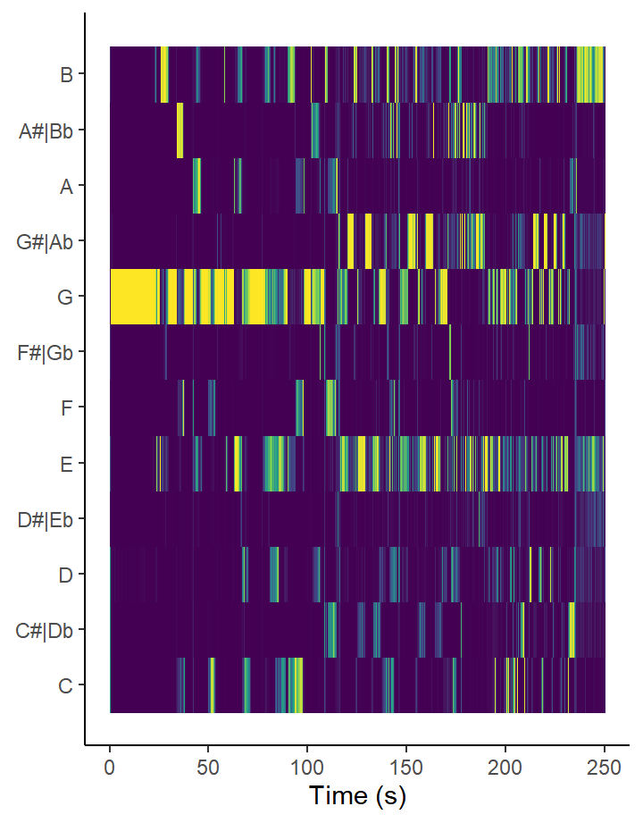

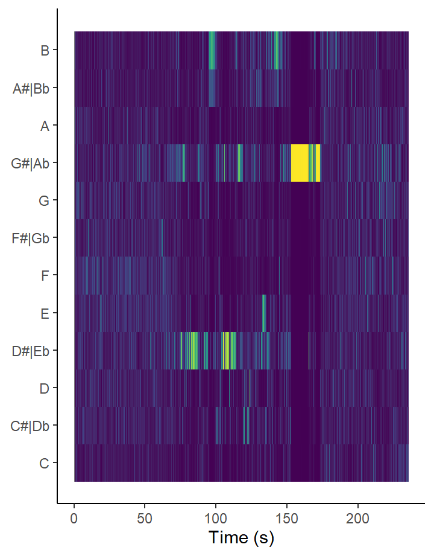

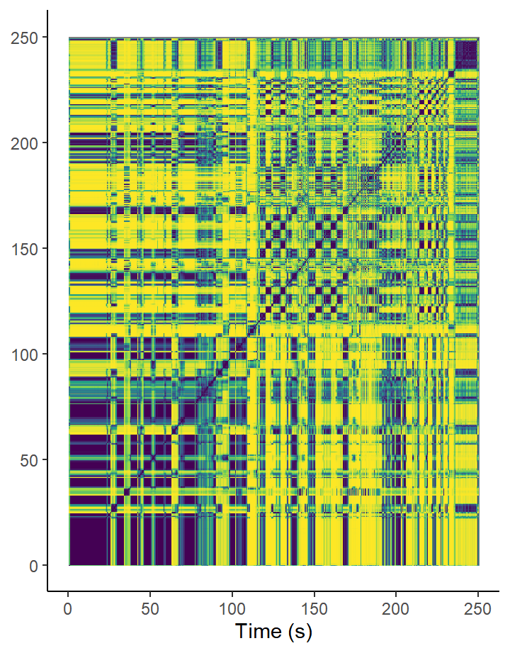

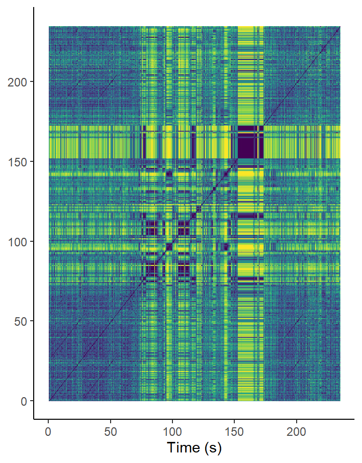

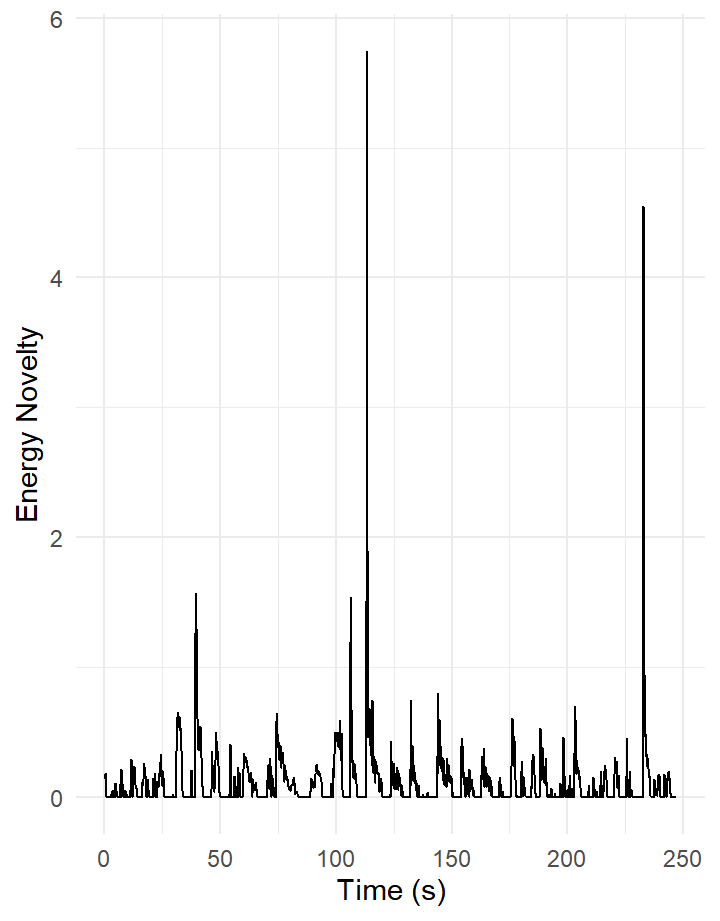

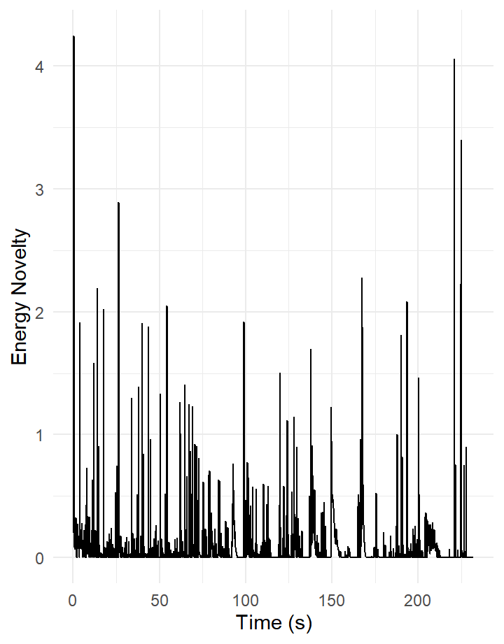

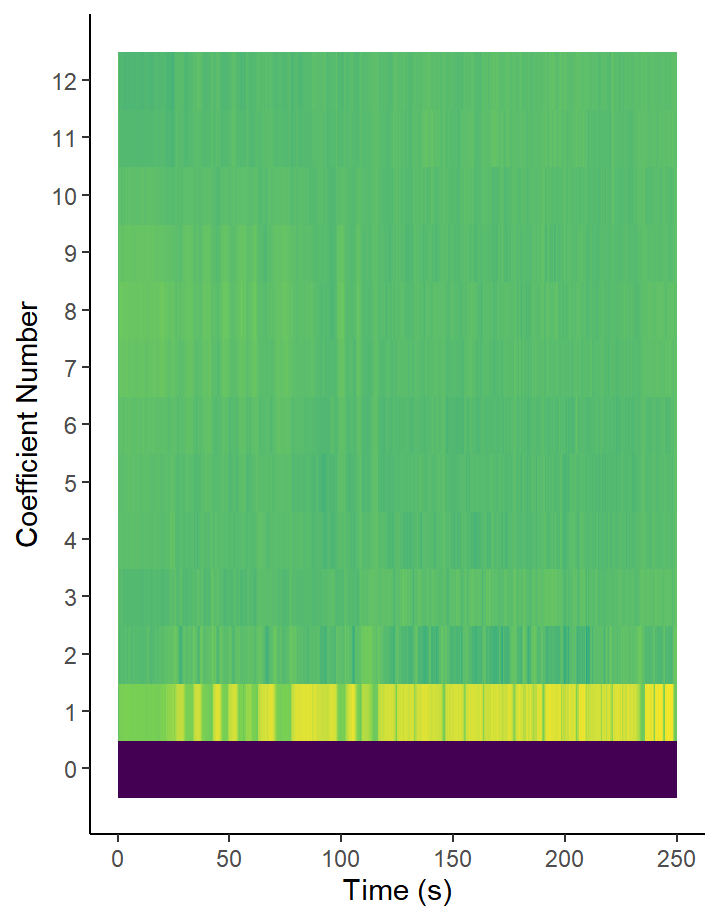

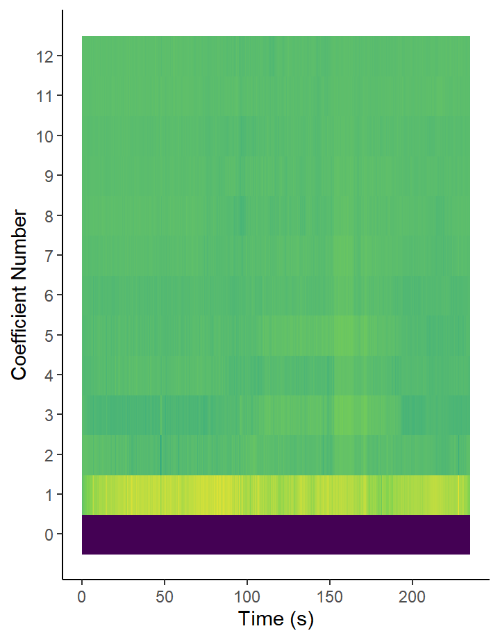

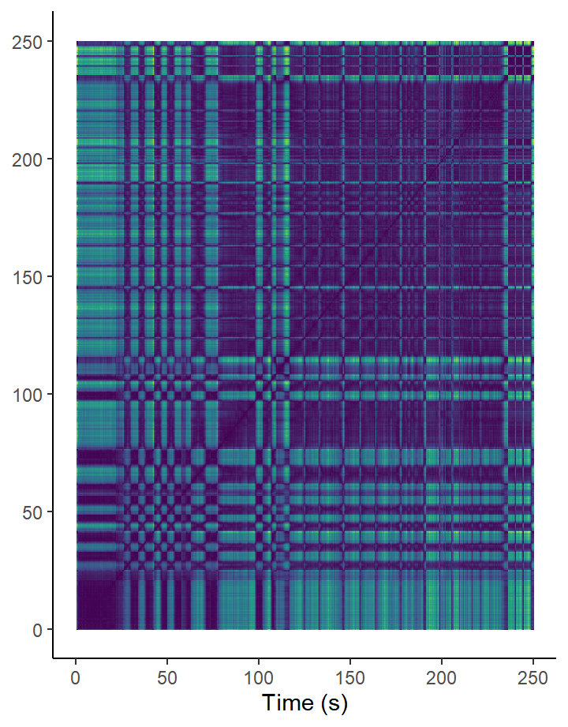

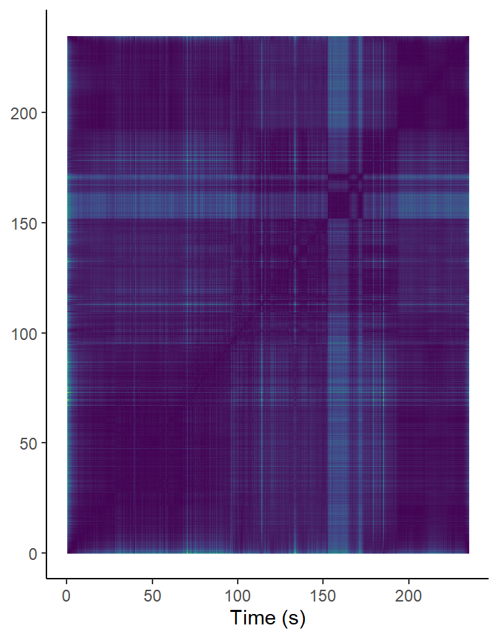

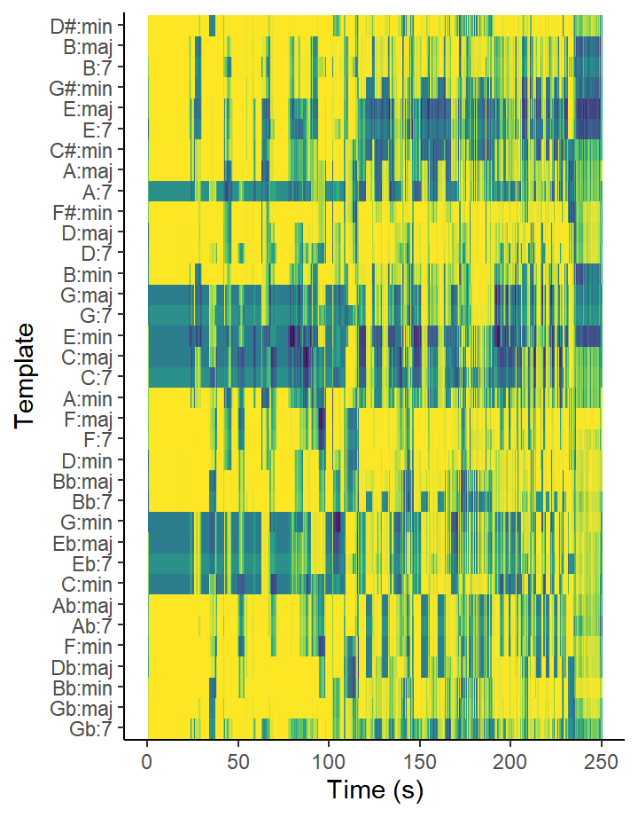

[10 more figures not shown]

# CLASS CORPUS

### Welcome!

Welcome to this flexdashboard. I will be investigating a class corpus that is comprised of both AI generated music and human composed music. First things first, I want to introduce the two tracks I contributed to this corpus.

First Track

[interactive chart not shown]

This is my own music that I composed. I am a composition student at the Tilburg conservatory and I composed it early 2024 for a saxophone quartet (soprano, alto, tenor, bass). It is the first movement of a larger 10 minute piece called The Water Bellows. It follows the story of a ship which meets an unfortunate end, inspired by the real-life HMAS Sydney II tragedy whose memorial I visited in Geraldton, Australia. The first movement covers the ship leaving the harbour (we can hear the ostinato mimicking a lighthouse) and the arrival of the danger (the blaring horns at the end of the movement). This recording is an extract from the performance played in the Eindhoven concert hall. The four players are Charlotte van Husen (bass), Javier Villegas (tenor), Karlo Zamic (alto), and Juan Velez (soprano).

Second Track

[interactive chart not shown]

This is also my own music, written in my 2nd year of conservatory. This was composed in early 2024 for a theater collective in Tilburg called EELT. They did a collaboration with the women’s emancipation center called Feniks and I was lucky enough to be asked to write an atmospheric piece to accompany their theater and dance performance. The sounds used in the piece are recorded audio from instruments but also locations, such as train stations. They were then processed in a DAW and effects were added. Since this piece is meant to accompany a performance, it is a lot simpler in terms of texture. It is also very different to use sounds to create music rather than notes like my previous piece.

Hop onto the next page to see how these pieces are situated in the class corpus!

### What does the class corpus look like?

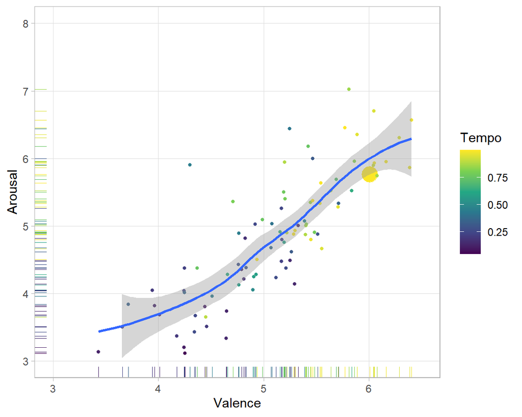

[interactive chart not shown]

Both my pieces, although very different from each other, are very far from a pop song. These features tend to be computed best with Western pop music so it makes sense that they both rank very low on most features. Essentia did managed to identify that they stand out from the rest of the corpus, especially from the AI generated songs which usually use these typical pop features and therefore can be computed more accurately and highly.

# CHROMA

### Let’s dive into pitch first. Here is a chromagram for my first track.

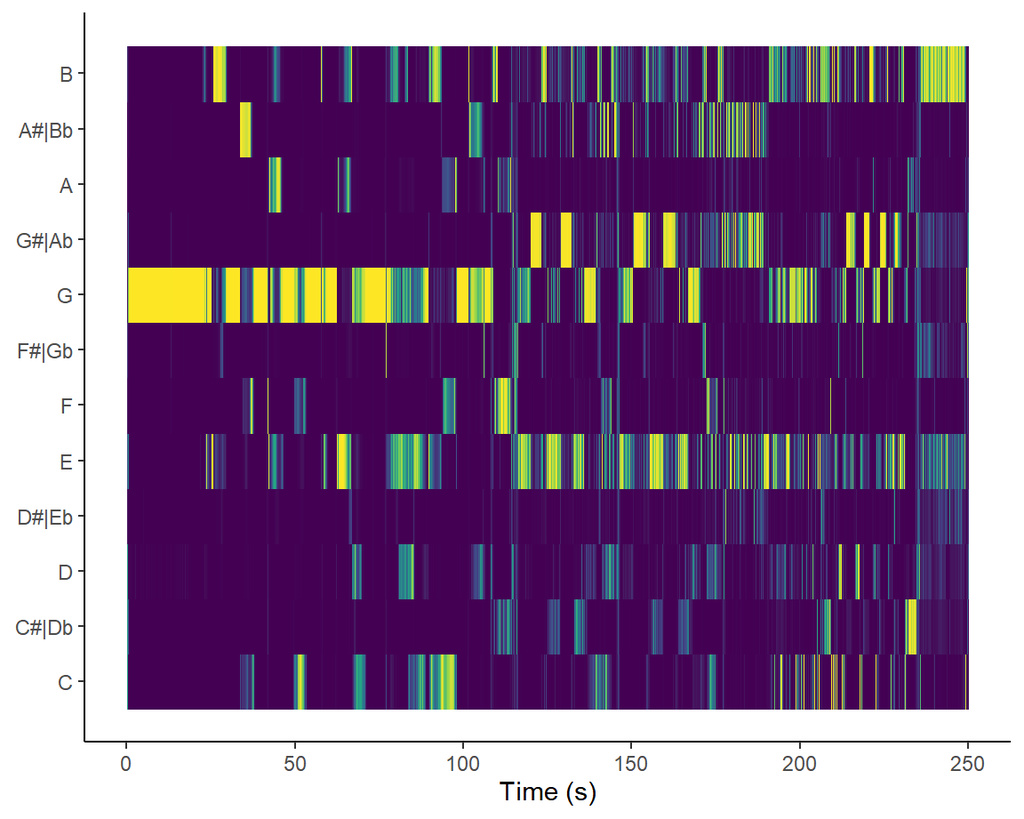

What is most interesting to note here is that my piece starts with an ostinato of G, clearly being shown in the chromagram. The chords that come through during this ostinato also show up very clearly and accurately. We can also see that the tonality remains in the same key where the I chord of the key (Gmajor) is dominant (G, B, D). We also see mediantics at play with the E minor chord being present. The middle of the piece gets more chroma which makes sense as a lot of arpeggios are playing. G# is present sometimes in the second half of the piece. I am wondering whether it could be that as the instruments warmed up when they played the piece, that the tuning went up and therefore G could get mistaken for G#. The piece ends on an open fifth being played three times, which is shown with the E and the B being highlighted. We also see F#, G#, D# lighting up. The D# can be explain by tuning issues for the E (which would also explain why the E isn’t lighting up as strong as the B), but I would love to know which overtones are making F# and G# show up.

### Similarly, here is a chromagram for my second track.

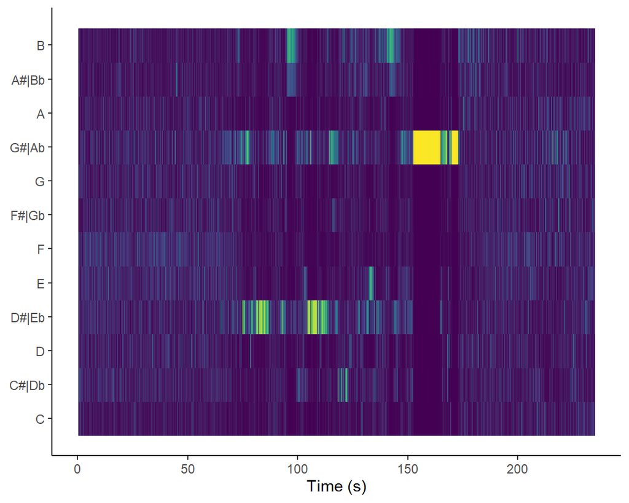

This is super interesting because this track is mostly atmospheric sounds recorded from a train station. This is reflected in the chromagram wonderfully. The only notes that are shown are when the instrument comes in in the middle. This chromagram almost shows structure better than pitch as three sections are clearly denoted (before the instrument, the instrument, after the instrument). when I played the instrument, I mostly taped a bunch of different notes but it seemed that this was interpreted here as primarily a G#. I wonder if this is because most of the notes had overtones that evoked G# too. We also see as second strongest pitch the D#, the fifth of G#. This would make sense in terms of overtones. The minor third also is seen but very light (B).

### Now let’s use a Self-Similarity Matrix to see repetitions, novelties, and homogeneity in my first track.

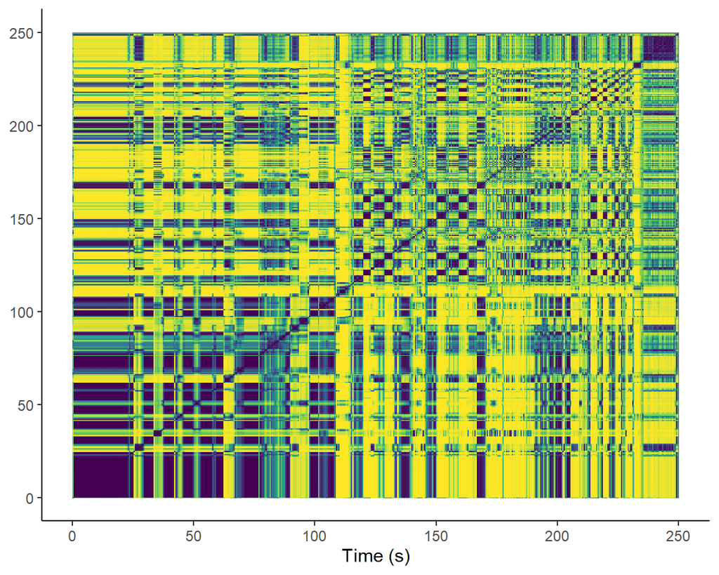

I find this interesting because the piece does include a lot of repeats yet the graph tells us that it composes of a lot of new notes.The beginning and end are clearly dark. This is because the beginning has that G ostinato and the end of the piece includes repeating open fifths thrice. Since it is a live performance, the repeats might be played slightly differently. I wonder if that could affect the way the matrix computes the material as new instead of repetition that has already happened. This was very surprising to me.

### Now let’s look at what a Self-Similarity Matrix would look like for an atmospheric piece that has very little musical pitches.

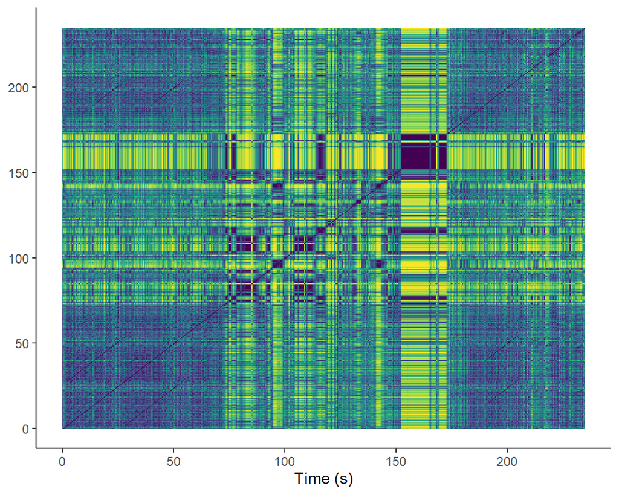

Here we see the same thing happen as with the chromagram where the novelty in yellow comes in when the instrument starts. It also creates a homogeneity square at around 80 and 110. I believe I have managed to link this to moments where a note struck will ring out with reverb, creating a moment of exact repeat. At around 150, there is a darker chunk. Through this representation, I realised that I had copy and pasted a section again, with the same notes ringing out with the same reverb. Although the playing seems improvised, when I look back into my DAW, I see that the original audio file I used wasn’t long enough so I reused a part of the beginning. This explains why there are similarities between the sections at 80 and 110 compared to 150.

# LOUDNESS

### Now that we delved into pitch and novelty in pitch, what about energy novelty? How loud is my piece?

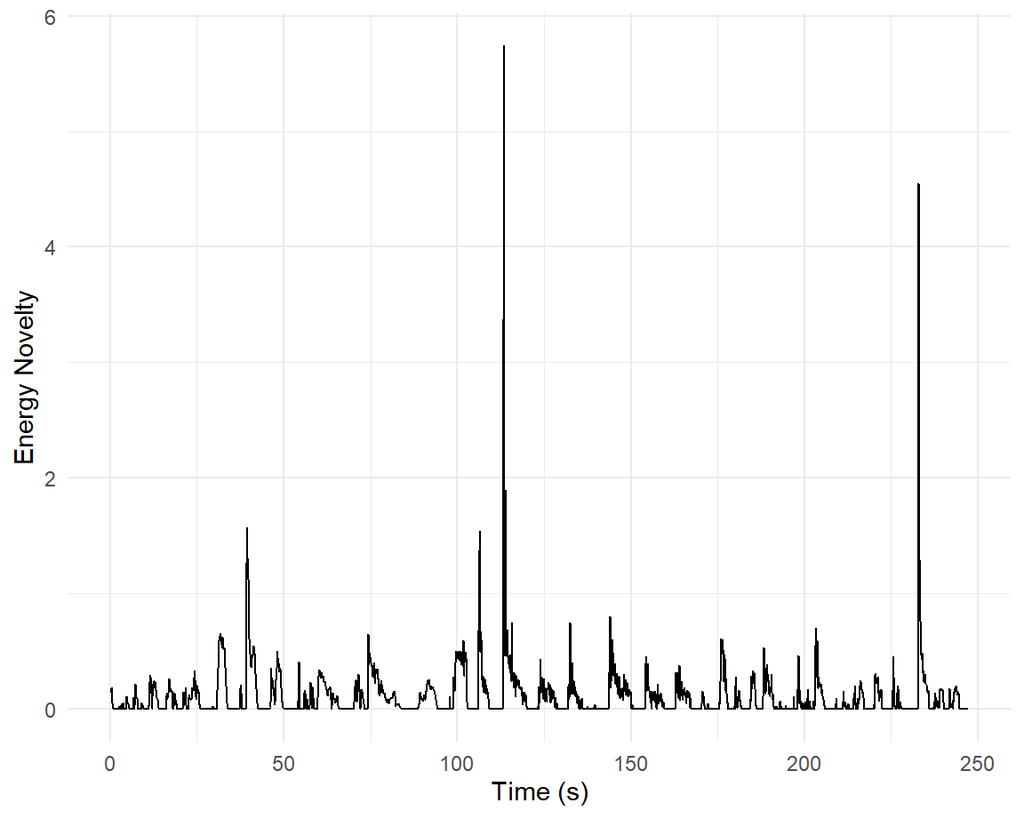

This graph is fantastic at showing when the chords arrive to accompany the main ostinato. The first very big spike comes from when the saxophones shift from the first section to the second. This shows how the energy increases suddenly when the notes increase due to the arpeggios. The small peaks between the two big ones aligned really well with the start of each phrase. Since I let my performers have moments to breathe in between the arpeggios, it creates a mini spike at the start of each phrase. The final big spike comes from the three large open fifths “horn” noises at the end. The repeats are denoted by the small two subsequent spikes.

### The previous track was acoustic and the recording came from a concert hall. I wonder how an electronic piece differs.

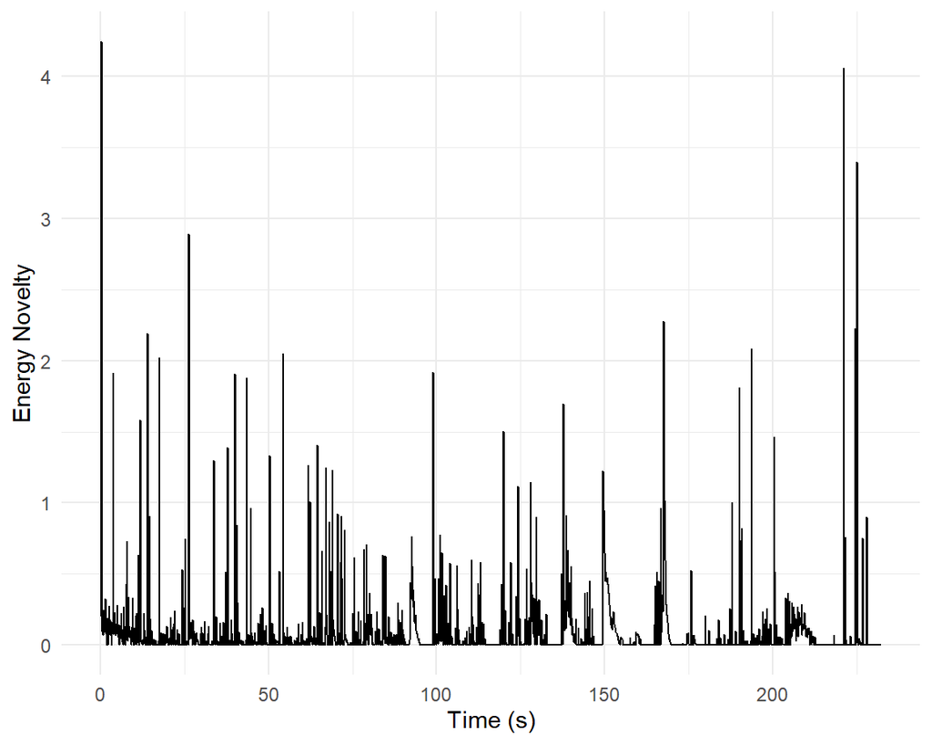

This electronic piece shows a lot more spikes in energy. This is very interesting as it is primarily an accompanying piece for a performance. The sounds I elected to use like trains or wind have a lot of dynamism in their nature. I believe that is what leads to all the spiking. When the instrument comes in around 65, the peaks become less elevated. This could be thanks to the reverb which softens the changes of energy. The instruments fades out around 160 seconds. This time, the spikes are less prevalent leading me to think it was the wind noises at the start that were the most unpredictable. I am curious about the final spike at the end, since my piece ends on a fade out.

# TIMBRE

### A cepstrogram, what can we glimpse?

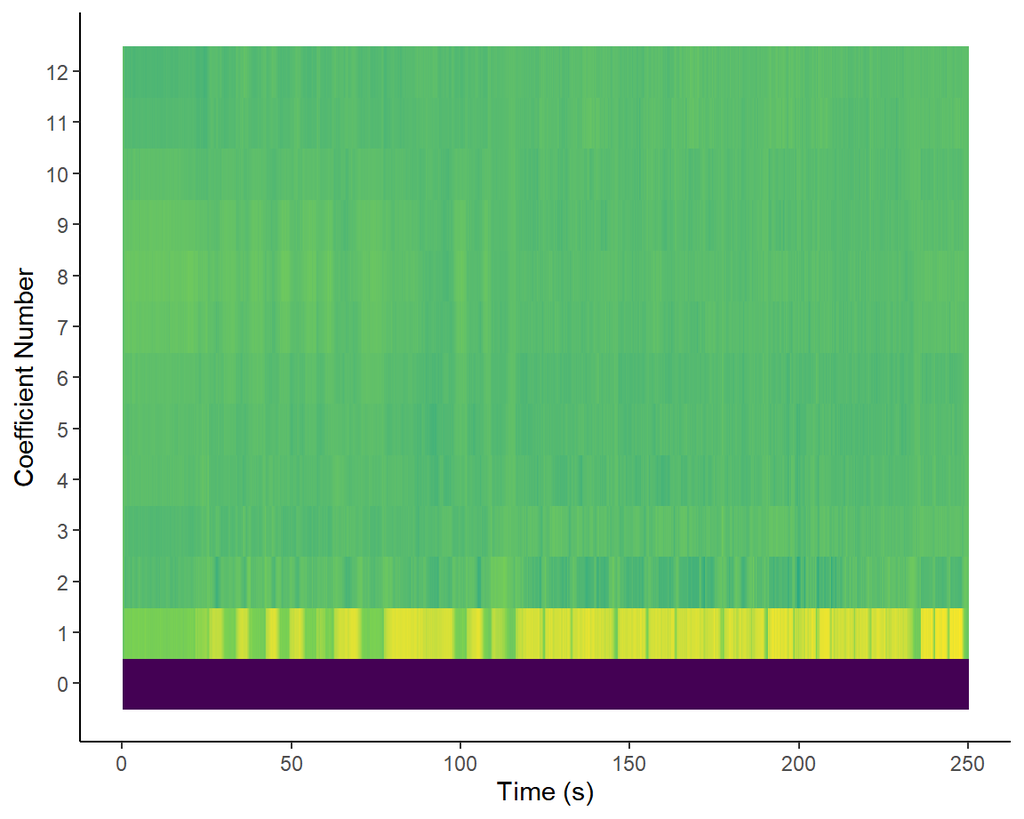

If we look at the first level, we see a darker section from the start - this clearly denotes the ostinato. Then lighter sections appear, the chords, before returning to the darker solo ostinato. At around 120, the colour is primarily yellow, indicating new material. This is interesting because like I have stated before, the repeats in my piece aren’t seen as repeats in most of the graphs. I believe a part of it is that it is a live performance so there are fluctuations in the repeats from human error. There are three final strips at the end, indicating the last three open fifths.

### More mysteries to uncover in this cepstrogram too.

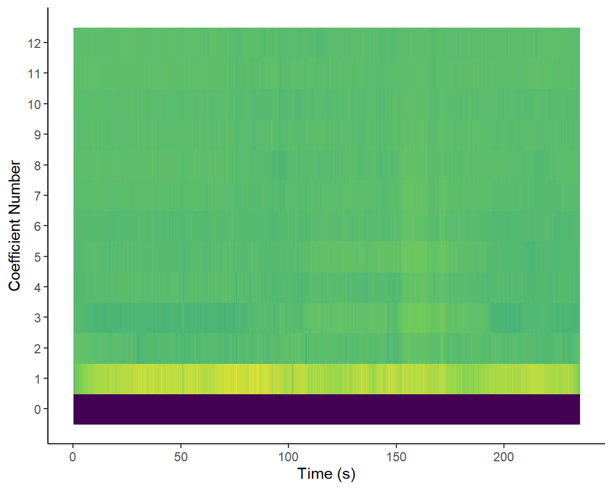

This cepstrogram follows the trend we tend to see with timbre for this piece. Overall, it is very homogenous, despite its varying sounds. On level 3, we see the structure of the instrument coming in and out (the lighter section). This is the same on the level 5.

### A Self-Similarity Matrix just like we saw before, but this time let’s look at timbre.

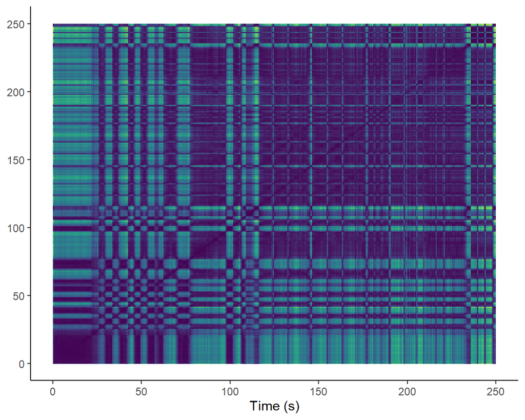

This makes a lot of sense. The piece is a sax quartet so there is not much that changes in terms of timbre. Here we can again also see that ostinato on G at the beginning, highlighted by the completely similarity of that one note repeating as that section is black at the start. There is some lighter sections, possibly when the other saxophones start joining. In the second half, they all play all the time which is why it then settles into dark quickly.

### What about track 2’s timbre? Any differences?

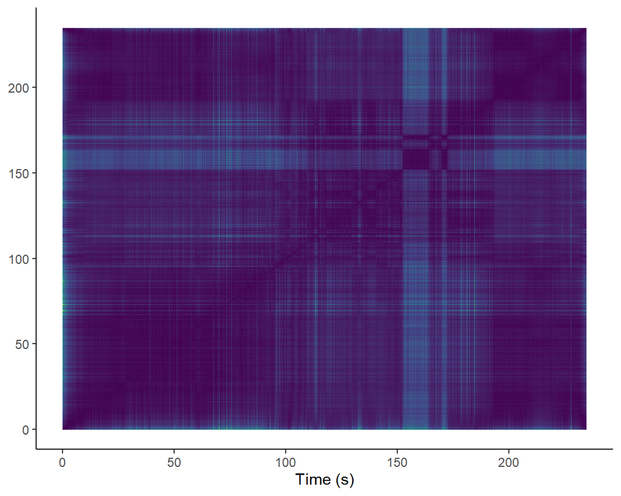

This matrix is intriguing because it doesn’t see any of the various sampled outside train sounds as different from one another. It seems because they’re all mechanical sounding or in the same range of pitch that they resemble one another. Funnily enough, in the same place as the dark square from the SSM for chroma, there’s a lighter patch in the timbre SSM.

# HARMONY

### Here is where things get really interesting. How accurate is this chordogram?

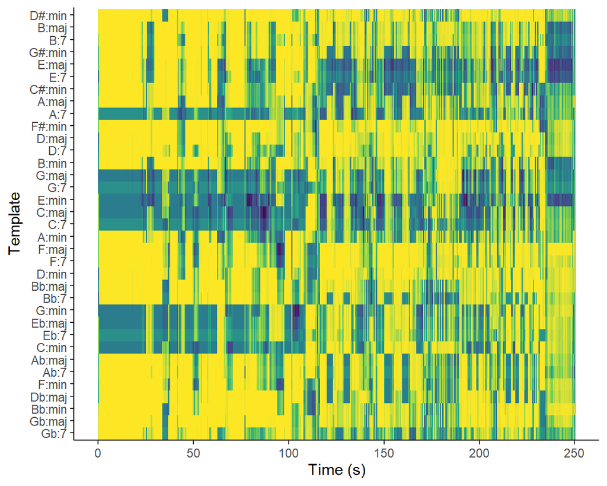

This is a chordogram of my first track. This second track is built with sampled outside sounds so it doesn’t make much sense to think of it in terms of chords and keys. I believe we have seen enough information with the chroma and SSM of the second track to understand that nothing fruitful would come.

Here we see that a lot of chords that include the note G are selected, whilst those who don’t have the note G as a major note in the chord are yellow. This must be because of the G ostinato at the beginning that the soprano saxophone holds. The beginning has three chord classifications: G, c, E (whether 7th chords, a minor chord, or a major chord). Eb chords are also prevalent, which explain why Cm is higlighted. I wrote this piece without a key, mostly just building chords around the note G so it makes sense to me for all the chords with a G to be present as I do rotate through a lot of weird clusters.

The arpeggios later in the piece don’t register as chords since the chordogram lacks the ability to group chroma by bar and have an overview of the general chord when the notes don’t fall at the same time. The final long fifths at the end of my piece are the darkest part of the chordogram. Two chords are selected: E major and E minor. This makes sense as the chord is an open fifth so it could go either way and the chrodogram would need to check the previous context of the piece in order to decide whether a major or minor third would make more sense with the fifths.

### What about the key? I’m love to find out since I didn’t compose in a specific key.

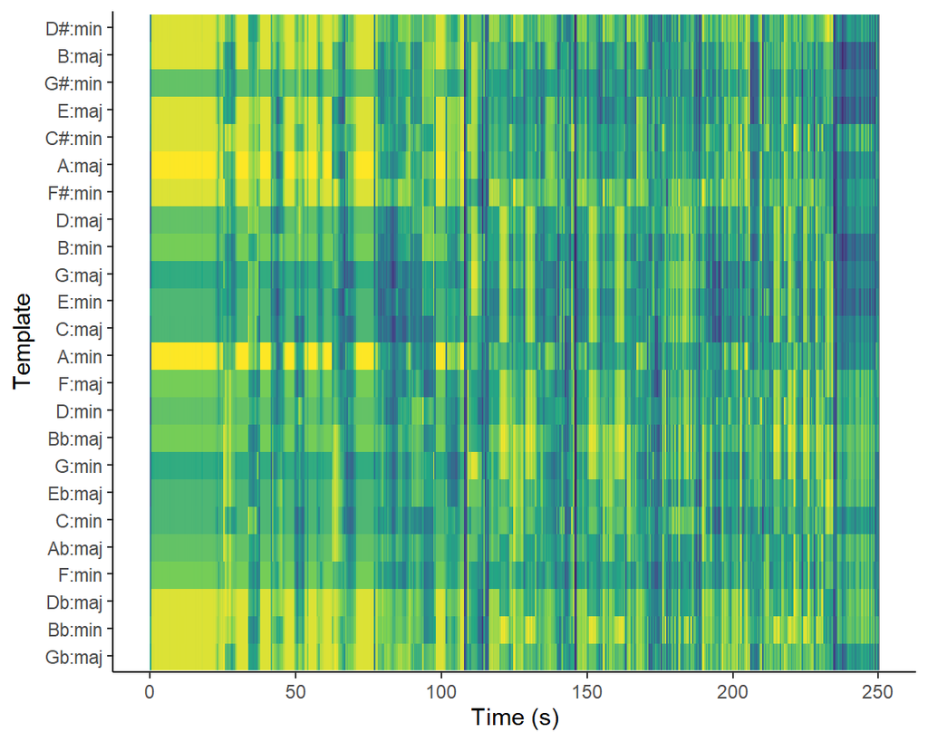

The keygram seems to be very confused as to what the key could be. This makes sense, as I mentioned before, I wrote this without a key with mind. All I had decided was the theme and that the center of tonality was G. With the context that the piece isn’t meant to have a key, I wonder if there is much information to be gleaned from this chart. I’ve also tried different norms and distances but it doesn’t get more defined than this. This reflects well the nature of how I composed but does not give us much information.

### Chordogram… How relevant can it be for a piece mostly made from found footage?

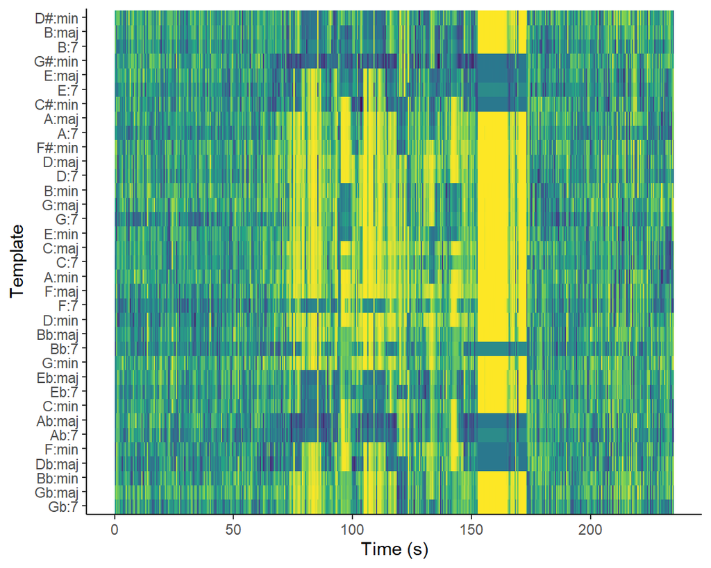

### What key are train tracks in?

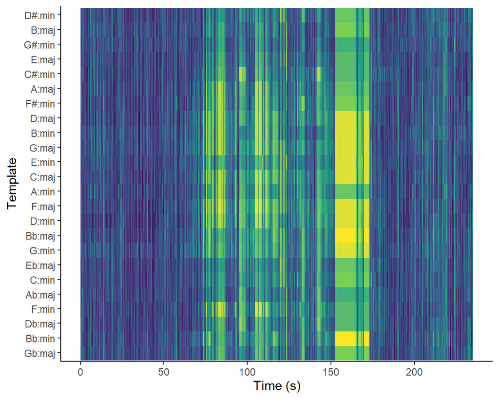

Similarly to the chordogram, the piece is accurately understood as keyless (just as how I though when I composed it). At 150, just as with the chordogram, we have the strongest indication of key. I do see the note B present in a lot of the keys, although Ab does remain unpresent. I wasn’t able to make sense of why some keys were highlighted whilst others not. It could be that because only mostly a G# was higlighted on the chromagram, it leaves the posibility open for a lot of keys, as long as they would contain a G#.

# TEMPO

### My sheet music tells me the bpm is 60. Let’s see if this tempogram agrees.

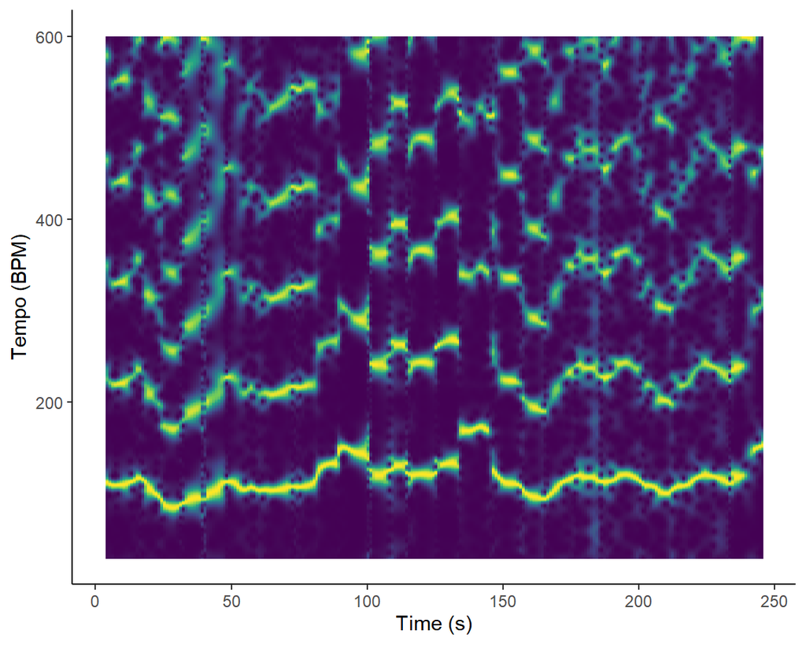

A tempogram for both my pieces doesn’t really make much sense. This first piece, I originally wrote 60 bpm on my sheet music. Since there are a very wide range of time signature within this first movement, this leads to a poor result. The time signatures in my piece are 4/4, 1/8, 3/8, 5/8, 2/4, and 7/8. I think maybe it could pick up on the regular 8th notes that time all these time signature together, but there are many tuplets and polyrhythms blurring this 8th note underlying pulse.

The graph shows a widly inconcsistent tempo. This could have some sense since this is performed by real people and they might fluctuate. Something I should mention is that I did give my players the liberty to take time in between phrases for breathing since this piece requires a lot of continous playing for all of them. This can also mess with the tempo perception.

Overall, you can see these regular tempo harmonics reflected in the piece. The first line seems to sit at 100 bpm, quite higher than the bmp on my sheet music.

### This piece was designed without a tempo.

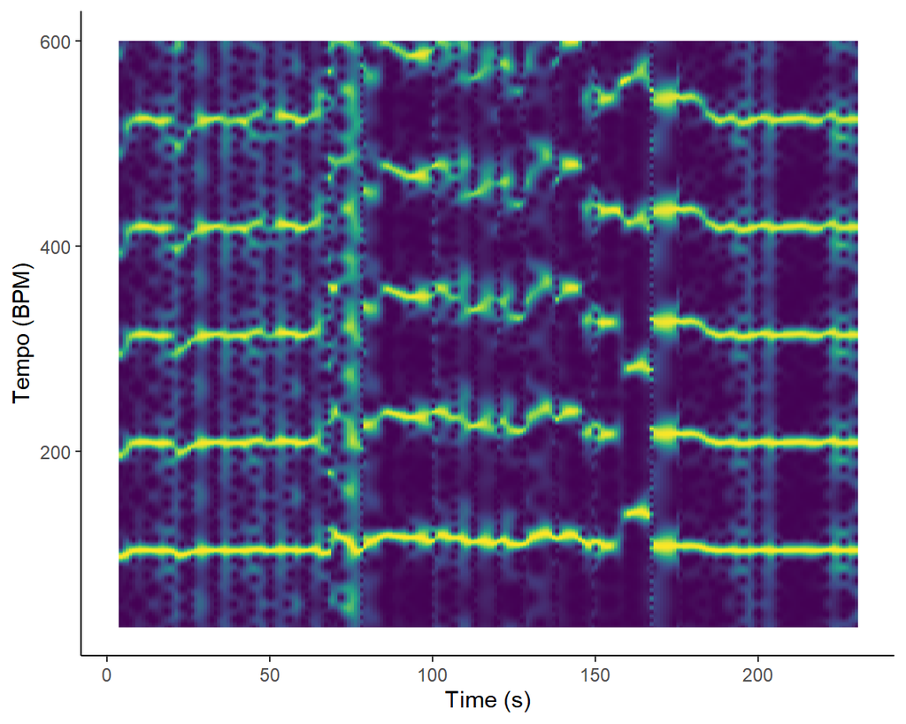

These piece was designed without a time signature. Since it is a collection of outside recorded sounds, they do naturally have a rhythmic percussive sound which might create these onsets. However, there is nothing connecting all these sounds to one another. Every sound comes in randomly, the template I used in my DAW worked with seconds and not bars. I find it interesting that it found a tempo so high since the middle part with the instrument is quite slow. Of course the huge amount of reverb and delay I put on the instrument probably didn’t help it understand whether it was a new onset or just the decay of the note.

### What about a cyclic tempogram?

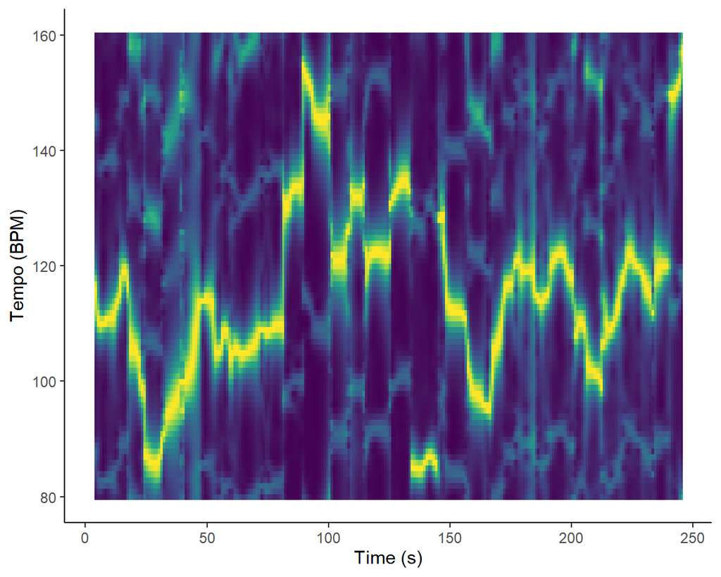

The cyclic tempogram shows tempos that vary wildly from one second to the next ranging from 85bpm to 145bpm. At the very end, despite the three long chords I have composed, the tempogram interprets this as even higher that 145bpm, which is fascinating. It must be very confused by the sudden slowness that it compensates by subdividing. At 140 seconds, the tempo drops from very high to very low. Since the bulk of the middle part are arppegios following the 8th notes of the piece, I believe it is the time signature changes that gets it to be confused as to where the one is. This is why the tempo doesn’t stay regular despite it being a very stable part of the piece. I’m very surprised with the cyclic tempogram that there is so much noise surrounding it since there isn’t that much noise in the standard tempogram.

### And here’s a cyclic tempogram for my second track.

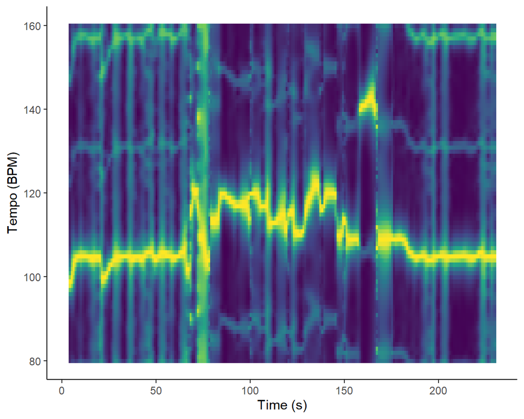

This cyclic tempogram has a lot more variation that the standard tempogram. Around the 160 second time mark, there’s a huge jump in tempo to 144. It looks like it lines up with the timbre and chroma difference at that time mark. I still have not been able to piece together what could be catching the attention of the program. You can also see the structure in this tempogram, the three parts this piece seems to be divided into where it is before the instrument, during, and after.

### Let’s zoom out and take a look at tempi in the class corpus.

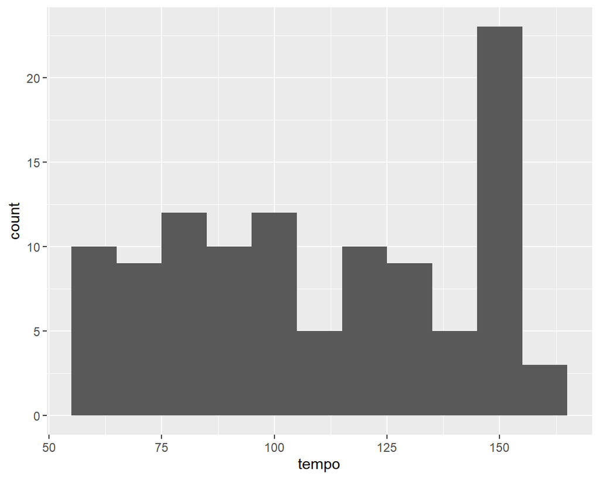

My two tracks were ultimately classified both at 154. What is interesting is that it belongs to the most popular tempo for tracks. Both my tracks are not 154, my first track is marked as 60 bpm on the sheet music and my second track has no tempo (it would not make sense). What’s interesting is that they are very different from one another in style, but got grouped into one tempo. 154bpm is also a bpm that is very high, most songs are not in this range. This leads me to question how accurate this all is. The bpm Essentia chose don’t reflect what happened in the (cyclic) tempograms neither. What makes this all the more confusing is that the songs at 154bpm are split 50/50 with whether it is AI or not. This makes it all the more intriguing about why this tempo is so popular (I would’ve though AI tracks would be all in the same range, but instead the AI song tempos span the whole range from 60 to 154 bpm).